# Sampling variation in the current HUB pipeline

# Scope

This replaces the archived low-level pilot. It uses canonical persisted `assump_*` fields, Tab 2/3/4 staging and real `Hub$build_results()` aggregation. One record is one appraisal person/trip under the current contract. **Whether the source trip weights need to be applied during source preparation remains under review.** Sampling variance cannot establish representativeness or correct systematic differences caused by ignoring survey weights.

The experiment holds supplied counts, assumptions, source and HM data fixed. The 40-year scheme has immediate, permanent effect. The normal configured new-user and induced-trip settings apply. REF trips are measured from one observed population; the trip targets below remain unchanged across replicate seeds. The population-size study requests 20% more trips. The cycling-volume study instead holds all 5,000 source people fixed and requests specified absolute increases of 100, 500 and 1,000 weekly cycling trips.

- **Whole appraisal:** repeat REF selection and CF allocation.
- **Fixed REF:** preserve one REF person/trip snapshot and repeat CF allocation.

These are complementary experiments, not an additive variance decomposition. Fixed REF conditions on one particular cohort, so its mean may differ from the whole-appraisal mean. Its SD need not be smaller in a short pilot. Population-size comparisons also use different observed trip totals and completion assumptions; they are realistic scenario comparisons, not an isolated sample-size experiment. Neither tests browser save/discard state. User/trip route sensitivity is examined separately in the matched-route report.

| Replicates | Successful | Failed |
| --- | --- | --- |
| 10 | 60 | 0 |

**This report is the cycling-trip-volume study:** all 5000 source people are assessed in each scenario; only the requested cycling-trip increase changes. These are not population-expanded estimates for the entire LAD. The earlier small-population study is retained separately.

Largest paired HALY difference between calculation paths: **0**. The paths are an implementation check; do not pool them as independent draws.

# Trip volumes behind the scenarios

Population size alone does not describe the intervention being tested. These are the **supplied weekly trip targets**, recovered from every successful run’s saved profile and checked for consistency across seeds and both experiments. They are not estimates recalculated from the population size, nor a new audit of realized trip rows. Combined scenarios list each mode separately.

| People | Scenario | Mode | REF trips/week | CF trips/week | Additional trips/week |
| --- | --- | --- | --- | --- | --- |
| 5000 | cycling | cycling | 695 | 795 | 100 |
| 5000 | cycling | cycling | 695 | 1195 | 500 |
| 5000 | cycling | cycling | 695 | 1695 | 1000 |

In the smallest cycling-trip increase (5000 people), **695 REF trips become 795 CF trips: 100 additional weekly trips**.

Walking and cycling scenarios with the same population do not necessarily describe equally sized interventions. Compare their additional trip volumes before interpreting differences in health-result variability.

Trip targets are fixed, but recipients and sampled activity doses can differ. The reported relative SD is **100 x SD(health benefit) / abs(mean health benefit)**, not SD of the trip count or SD divided by trips. A large percentage can describe a small absolute fluctuation around a small health benefit. Dividing all health results by the same fixed number of additional trips would not change this relative SD; it would only change the units of the mean and absolute SD.

# Health-result variation

Read the mean together with the SD: a small absolute difference can be a large percentage when the expected benefit is close to zero. Start with HALYs below, then inspect which recipients and activity doses differ in the saved diagnostics. Do not interpret the spread between the two experiment means as random error.

Benefits use unrounded `all_modes` health-cube values over cycles 1-40: CF minus REF for HALYs; REF minus CF for deaths and disease events. Do not sum different outcome units. Relative SD is suppressed near zero mean benefit. With fewer than 100 repetitions, tail ranges and sign frequencies are pilot diagnostics. Empirical sampling ranges are not confidence intervals for true health effects, and exclude uncertainty in assumptions and HM parameters. Each plot panel has its own y-axis scale. Compare numerical SDs and relative SDs, not the visual height of the point clouds across different panels.

**Colour key:** green/teal means **Fixed REF** (repeat CF allocation from one unchanged REF); pink/red means **Whole appraisal** (repeat staging and CF allocation). These colours are **not REF versus CF**. Each dot is one run’s health benefit over 40 years: **absolute HALYs gained** or **absolute deaths prevented**, not a rate per 100,000 and not a percentage. Fractional deaths represent expected counts. The horizontal categories are the two experiments; small sideways jitter only keeps dots visible and has no numerical meaning.

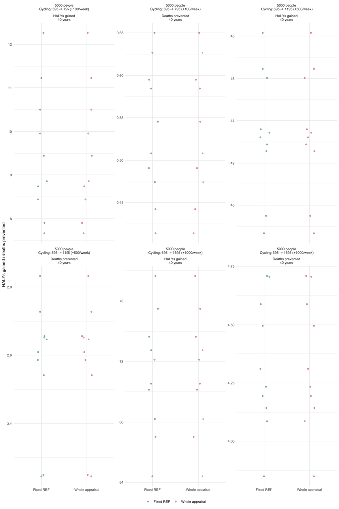

| People | Weekly trips: REF -> CF (change) | Experiment | Outcome | Draws | Mean benefit | SD of benefit | Relative SD (%) |
| --- | --- | --- | --- | --- | --- | --- | --- |
| 5000 | Cycling: 695 -> 795 (+100/week) | fixed_ref | halys | 10 | 9.5000 | 1.4858 | 15.6397 |
| 5000 | Cycling: 695 -> 795 (+100/week) | fixed_ref | mortality | 10 | 0.5330 | 0.0799 | 14.9834 |
| 5000 | Cycling: 695 -> 795 (+100/week) | whole_appraisal | halys | 10 | 9.5000 | 1.4858 | 15.6397 |
| 5000 | Cycling: 695 -> 795 (+100/week) | whole_appraisal | mortality | 10 | 0.5330 | 0.0799 | 14.9834 |
| 5000 | Cycling: 695 -> 1195 (+500/week) | fixed_ref | halys | 10 | 43.4495 | 2.9319 | 6.7478 |
| 5000 | Cycling: 695 -> 1195 (+500/week) | fixed_ref | mortality | 10 | 2.5746 | 0.1900 | 7.3799 |
| 5000 | Cycling: 695 -> 1195 (+500/week) | whole_appraisal | halys | 10 | 43.4495 | 2.9319 | 6.7478 |
| 5000 | Cycling: 695 -> 1195 (+500/week) | whole_appraisal | mortality | 10 | 2.5746 | 0.1900 | 7.3799 |
| 5000 | Cycling: 695 -> 1695 (+1000/week) | fixed_ref | halys | 10 | 71.1866 | 3.9964 | 5.6140 |
| 5000 | Cycling: 695 -> 1695 (+1000/week) | fixed_ref | mortality | 10 | 4.3316 | 0.2851 | 6.5808 |
| 5000 | Cycling: 695 -> 1695 (+1000/week) | whole_appraisal | halys | 10 | 71.1866 | 3.9964 | 5.6140 |
| 5000 | Cycling: 695 -> 1695 (+1000/week) | whole_appraisal | mortality | 10 | 4.3316 | 0.2851 | 6.5808 |

**Note**

These are fresh diagnostic runs, not the proposed final 100-replicate study. The main comparison above concerns HALYs and mortality; all disease-specific summaries remain in the generated `summary.csv` rather than being added together. `summary_with_trip_context.csv` includes the same full statistics with mode-specific trip context; `scenario_trip_inputs.csv` supplies the separate numeric trip columns.

# Aggregated variability plots

The following plots use **whole-appraisal results only**, not a pooling of the two calculation paths. Each point summarizes ten seeds in the current pilots. Lines connect the tested scenarios; they are not fitted predictions or confidence bands. We plot **SD** (in the outcome’s original units) and **relative SD** (%) rather than squared-unit variance; the exported summary also contains `variance = sd^2` for analyses that require variance itself.

## Variability versus additional cycling trips

This comparison holds the assessed population at 5,000 people. Its horizontal axis is **additional cycling trips per week**, not population size or number of Monte Carlo repetitions. Relative SD has the same percentage scale across both outcomes. In the second plot, bars show **mean plus/minus one SD**, not a confidence interval. The y-axis scale is fixed across trip increments within each outcome, but HALYs and deaths retain separate outcome scales.

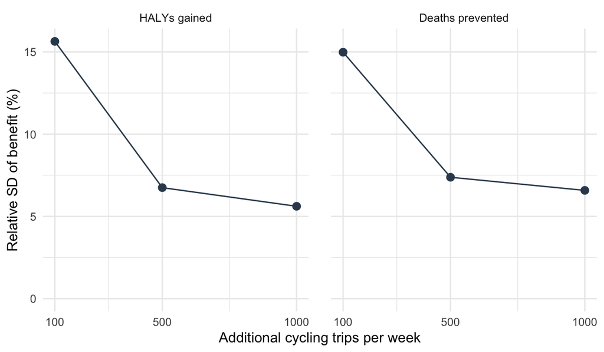

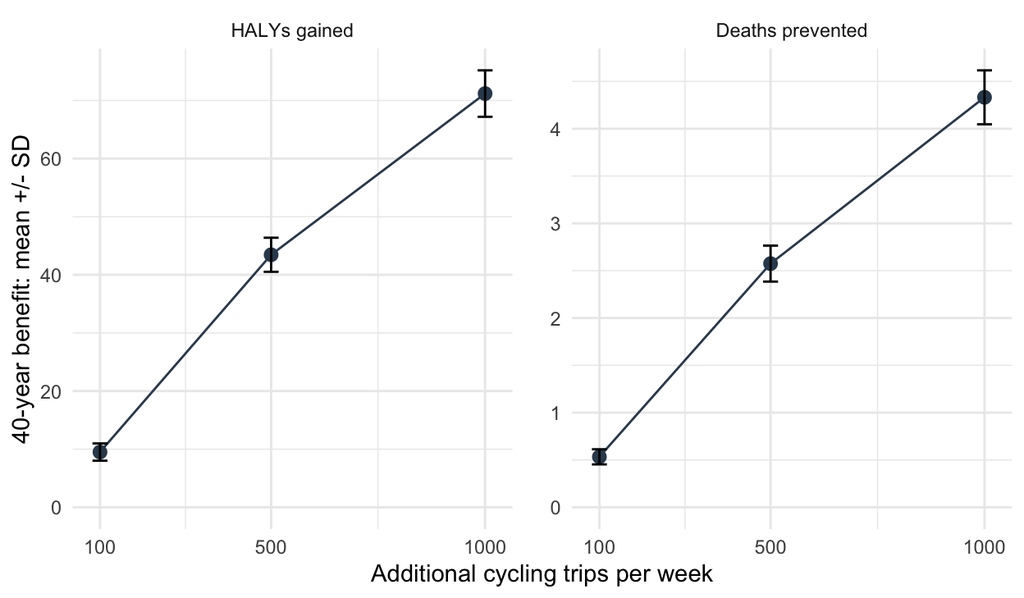

## Variability versus assessed population

This uses the **earlier 100/500/1,500-person study**, not the new fixed-5,000 design. Colour denotes the active modes in this plot, as labelled in its legend. The horizontal axis is assessed people, not the number of repetitions. All panels share the same relative-SD percentage scale.

**This is not a pure sample-size effect:** trip increments and completion assumptions also differ between those scenarios. For example, cycling adds 5/14/41 weekly trips, whereas walking adds 74/512/1,470. Labels below show the trip increases; do not interpret the lines as controlling for intervention size.

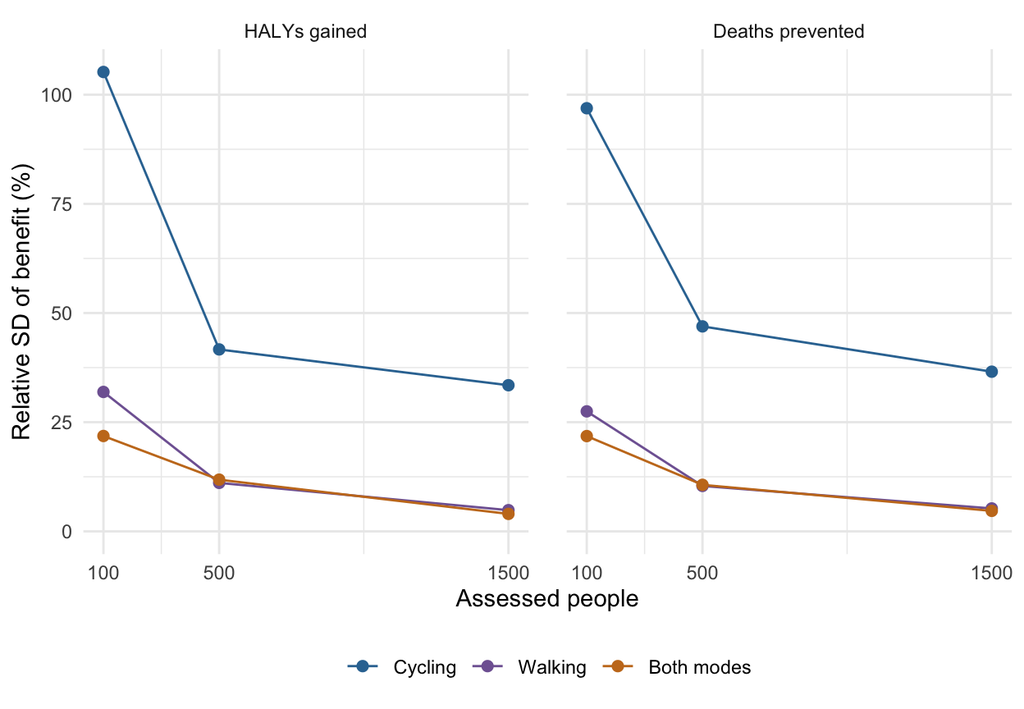

| People | Scenario | Mode | Additional trips/week |
| --- | --- | --- | --- |
| 100 | cycling | cycling | 5 |
| 100 | walking | walking | 74 |
| 100 | walking+cycling | cycling | 5 |
| 100 | walking+cycling | walking | 74 |
| 500 | cycling | cycling | 14 |
| 500 | walking | walking | 512 |
| 500 | walking+cycling | cycling | 14 |
| 500 | walking+cycling | walking | 512 |
| 1500 | cycling | cycling | 41 |
| 1500 | walking | walking | 1470 |
| 1500 | walking+cycling | cycling | 41 |
| 1500 | walking+cycling | walking | 1470 |

# Diagnostics and failures

The diagnostics CSV contains changed-person counts, recipient age and baseline activity, MMET changes, donor copies and extra trip rows. Run-level RDS files retain profiles, person-level exposure, and the sampling report containing current/new users, shifted/induced trips and donor fallbacks. Failure rows are retained; successful-run summaries can be misleading if failures are systematic.

| id | status | warnings |
| --- | --- | --- |

| Generated | Commit |
| --- | --- |
| 2026-09-10 20:47:02.264349 | 7ec3f0bba423861305794433a209e479964c9584 |

# Reproduction

**Rendering the saved results does not rerun the simulation.** From `docs`:

```bash
quarto render sampling_variance_evaluation.qmd --to html
quarto render sampling_variance_evaluation.qmd --to pdf
```

Only to generate a new simulation batch, from HUB root:

```r
pkgload::load_all(".")
source("inst/workflows/dev_sampling_variance.R")
run_sampling_variance(n_replicates = 100)
```

For the larger cycling-trip study, hold the full source population fixed:

```r
run_sampling_variance(n_replicates = 10,
  additional_cycling_trips = c(100, 500, 1000),
  output_dir = "docs/_sampling_variance_cycling_trips")
```

Render this batch by passing `-P data_dir:_sampling_variance_cycling_trips` and a separate output name, such as `--output cycling_trip_scale_variance.pdf`. The increases are total additional cycling trips, not shifted-only targets: the unchanged induced-trip assumption still applies. With all source people included, the whole-appraisal arm cannot measure geographic person-subset variation; differences from fixed REF can still involve trip allocation or staging. This is an intervention-volume comparison, not a larger source sample.

Render from `docs`: `quarto render sampling_variance_evaluation.qmd`. Runs are fresh, never reused from the old pilot cache. The manifest saves configuration, seeds, source/code/data fingerprints and the R session. The original implementation is retained under `docs/archive/`, not used here.

# Appendix: assumptions and provenance

Defaults are resolved once per scenario with `prepare_assumption_profile()`. Every final profile and `get_appraisal_assumptions()` output is saved. Effective values and provenance must have the same signature across repetitions, or the run is recorded as an error. Card applicability may change after accepting generated counts without the underlying values changing.

| scenario | field | value | source |
| --- | --- | --- | --- |
| 5000_cycling_plus100 | assump_induced_trips_percent | 10 | Configured preference |
| 5000_cycling_plus100 | assump_trip_source_shares_bike | {“car”:{“percent”:63.2142},“walk”:{“percent”:28.2257},“pt”:{“percent”:8.5602}} | REF/source trip distribution |
| 5000_cycling_plus100 | assump_trips_per_user_per_week_bike | 4.4839 | REF population |
| 5000_cycling_plus100 | assump_trip_distance_km_bike | 7.0054 | REF population |
| 5000_cycling_plus100 | assump_trip_duration_min_bike | 28.3755 | REF population |
| 5000_cycling_plus100 | assump_trip_speed_kmh_bike | 15.7 | Fixed fallback |
| 5000_cycling_plus100 | assump_new_user_percent | 10 | Configured preference |
| 5000_cycling_plus100 | assump_new_user_activity_pattern | “observed_donor_patterns” | Implemented sampling policy |
| 5000_cycling_plus500 | assump_induced_trips_percent | 10 | Configured preference |
| 5000_cycling_plus500 | assump_trip_source_shares_bike | {“car”:{“percent”:63.2142},“walk”:{“percent”:28.2257},“pt”:{“percent”:8.5602}} | REF/source trip distribution |
| 5000_cycling_plus500 | assump_trips_per_user_per_week_bike | 4.4839 | REF population |
| 5000_cycling_plus500 | assump_trip_distance_km_bike | 7.0054 | REF population |
| 5000_cycling_plus500 | assump_trip_duration_min_bike | 28.3755 | REF population |
| 5000_cycling_plus500 | assump_trip_speed_kmh_bike | 15.7 | Fixed fallback |
| 5000_cycling_plus500 | assump_new_user_percent | 10 | Configured preference |
| 5000_cycling_plus500 | assump_new_user_activity_pattern | “observed_donor_patterns” | Implemented sampling policy |
| 5000_cycling_plus1000 | assump_induced_trips_percent | 10 | Configured preference |
| 5000_cycling_plus1000 | assump_trip_source_shares_bike | {“car”:{“percent”:63.2142},“walk”:{“percent”:28.2257},“pt”:{“percent”:8.5602}} | REF/source trip distribution |
| 5000_cycling_plus1000 | assump_trips_per_user_per_week_bike | 4.4839 | REF population |
| 5000_cycling_plus1000 | assump_trip_distance_km_bike | 7.0054 | REF population |
| 5000_cycling_plus1000 | assump_trip_duration_min_bike | 28.3755 | REF population |
| 5000_cycling_plus1000 | assump_trip_speed_kmh_bike | 15.7 | Fixed fallback |
| 5000_cycling_plus1000 | assump_new_user_percent | 10 | Configured preference |
| 5000_cycling_plus1000 | assump_new_user_activity_pattern | “observed_donor_patterns” | Implemented sampling policy |